# 0167-empiricalyang-9noun-hfrule-adults-fastproduction

Kathryn Schuler

last updated 2017-02-01

This experiment was conducted by Kathryn Schuler (graduate student) and Elissa Newport (advisor) and was based on a theory and computational model proposed by Charles Yang (U. Penn) and the declarative-procedural memory circuit framework proposed by Michael Ullman (Georgetown University). The lab manager at the time of running was Jaclyn Horowitz and the research assistant involved in this project was Gabriella Iskin (undergraduate RA). The data was collected at Georgetown University from November 11, 2016 to ONGOING.

- This experiment was reported in:
  - nothing, yet.
- And is planned to be reported in:
  - 2017 - Katie’s job talk at Penn
  - 2017 - Katie’s dissertation

# Introduction

# Materials and Method

## Subjects

- Adults:
  - 21 adults recruited at Georgetown University (13 female)
  - additional 2 excluded for failing to complete the study (2 male)
  - native English speakers (but multilingual permitted)
  - compensated $15.00 ($10.00 with a $5.00 bonus)

## Materials

### Equipment

- Hardware:
  - Macbook Air (OSX)
  - Sennheiser HD555 open-air headphones
  - Internal microphone of Macbook Air
- Software: Python, PsychoPy
  - Note: Audacity used for some recordings as PsychoPy’s microphone API unreliable

### Language

- 15 total nouns:
  - 9 familiar: `mawg`, `tombur`, `glim`, `zup`, `spad`, `daygin`, `flairb`, `clidam`, `lapal`
  - 6 novel: `bleggin`, `daffin`, `norg`, `sep`, `flugit`, `geed`
- 1 verb: `gentif` (means “there is” or “there are”)
- 7 plural markers:
  - 1 regular form: `ka` (applied to most frequent nouns)
  - 6 exceptions: `po`, `lee`, `bae`, `tay`, `muy`, `woo`
- Sentences constructed:
  - Singular: `V` + `N` + `null` (e.g. `gentif mawg`)
  - Plural: `V` + `N` + `MARKER` (e.g. `gentif mawg ka`)
- Conditions:
  - 5R4E Exposure: 5 most frequent types take the regular form `ka` and 4 remaining types take exceptions.
    - Language A: Noun rank in Zipfian distribution is as listed above (`mawg` is most frequent)
    - Language B: Noun rank is reversed (`lapal` is most frequent)
  - 3R6E Exposure: 3 most frequent types take the regular form `ka` and 6 remaining types take exceptions.
    - Language A: Noun rank in Zipfian distribution is as listed above (`mawg` is most frequent)
    - Language B: Noun rank is reversed (`lapal` is most frequent)

### Stimuli

- Images of “toasters” and pre-recorded words (adult female voice)
  - Mechanical turk version uses written sentences
- Exposure set:
  - 72 total sentences paired with corresponding picture
  - each noun is paired with a specific plural marker (see Language)
  - 1/3 of presentations were singular and 2/3 plural for each noun
  - plurals appeared in groups of 2, 4, or 6
  - Zipfian distribution
- Production test set:
  - All novel nouns presented twice: `bleggin`, `daffin`, `norg`, `sep`, `flugit`, `geed`
  - plurals appeared in groups of 3 or 5
- Rating test set:
  - All 9 familiar nouns presented 4 times in 2AFC
    - paired with four different incorrect markers

## Procedure

- Exposure:
  - see a picture and hear the sentence that goes with the picture
  - repeat the sentence
  - break every 18 trials (for sticker)
- Production test:
  - modeled after wug test (Berko, 1958)
  - see a singular picture and hear corresponding sentence
  - participant asked to produce plural sentence for same noun
  - importantly, adults are given a 1.5 second time limit
    - hear a beep and box on screen turns red
    - told they will get a 50 cent bonus for every trial on which they can produced within the time limit
- Rating test:
  - 2AFC test in which there is a child in a purple shirt and a child in a green shirt on the screen
  - participant must decide which child said the sentences correctly in silly speak

# Results and analysis

## Preregistration

#### Planned number of subjects

We will run 10 subjects in each condition (5R4E and 3R6E) to compare with our original yang experiment (0161)

- Update 2016-12-12: Research assistant accidentally ran 5 additional subjects in 5R4E, so we have expanded to 15 in each condition to balance this out.

#### Planned data cleaning

We will exclude participants who:

- are flagged for exclusion via KDS.exclude because:
  - did not meet inclusion criteria (age, language experience, normal to corrected-to-normal hearing/vision)
  - did not complete the study
  - equipment malfuncation during experiment

#### Planned analyses

We plan to run the same analysis we always run on our empirical yang work.

1. Simple t-tests against hypothesized values (100% for rule formation, 14.79% for chance, and token frequency of regular)
2. Comparision of the two conditions may be required (do they apply the regular form more in 5R4E than 3R6E?)
3. Comparision of this experiment to participants in the original yang experiment (0161) may be required - do pariticpants apply the regular form significantly less in 3R6E and signficantly more in 5R4E?

### Included in analysis

The following describes the participants that were included in analysis for both experiment conditions.

| condition | n.subjs | n.female | min.age | max.age | mean.age | sd.age |
| --- | --- | --- | --- | --- | --- | --- |
| 3R6E | 6 | 3 | 18 | 22 | 20.16667 | 1.471960 |
| 5R4E | 15 | 10 | 18 | 26 | 20.06667 | 2.548576 |

### Excluded from analysis

The folowing participants were excluded from analyses. Reasons for exclusion are given in the notes.

| condition | subject | gender | age | notes |
| --- | --- | --- | --- | --- |
| 3R6E | S19 | male | 21 | only went through level 1 |
| 3R6E | S23 | male | 20 | Program crashed after 1st production trial |

## Production Data

We ask the following questions in our analysis (for both children and adults):

- Does the Tolerance Principle predict when learners will form a productive rule?
  - Do learners use the regular form on 100% of test trials (strongly generalize/form a rule)?
  - Or do learners use the regular form no more than what we expect by chance (strongly resist rule formation)?
  - Or do learners match the input frequency of the regular form (probability match)?

### Group data

Usage of plural marker in production test by age group

| Condition | type | plural.marker | n.subjs | Mean | SD | SEM |
| --- | --- | --- | --- | --- | --- | --- |
| 3R6E | novel | e | 6 | 16.11 | 20.59 | 8.41 |
| 3R6E | novel | null | 6 | 39.02 | 48.11 | 19.64 |
| 3R6E | novel | R | 6 | 44.87 | 37.38 | 15.26 |
| 5R4E | novel | e | 14 | 2.69 | 6.86 | 1.83 |
| 5R4E | novel | null | 14 | 17.93 | 34.16 | 9.13 |
| 5R4E | novel | R | 14 | 79.38 | 33.36 | 8.92 |

### Plot of group data

The dashed lines indicate the frequency of the regular form in the learners exposure.

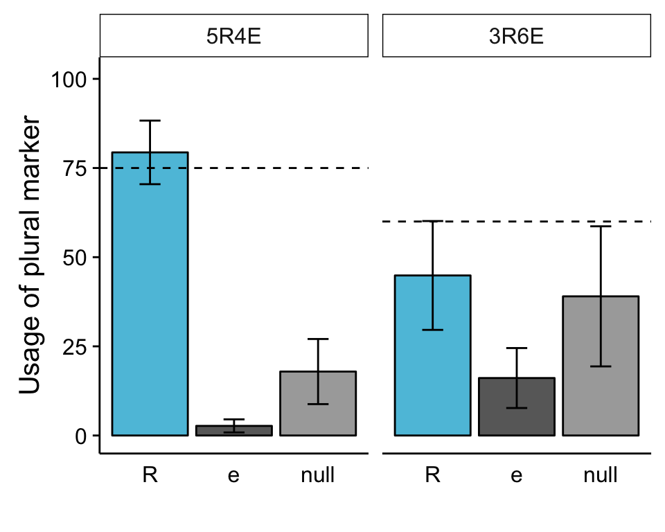

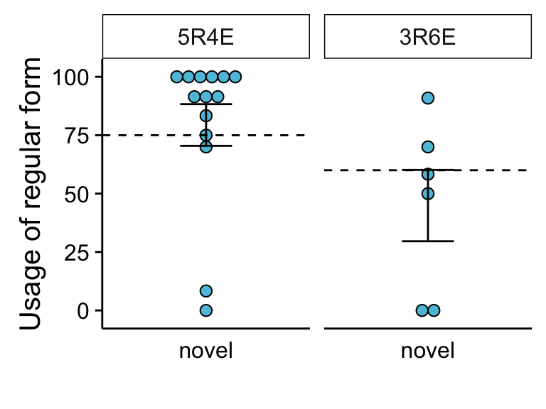

## Rating Data

[output not shown]